# Seguridad Tablero Movil Filtracion Base

Eduardo Alanis

2025-03-22

### Notas de Jair

- Se utiliza **Leaflet.JS** y datos abiertos de incidencia delictiva a nivel nacional, con énfasis en los datos del estado de Hidalgo a nivel municipal y mensual para los **40 delitos** reportados.
- Los datos abiertos se descargarán de: [Datos abiertos de incidencia delictiva](https://www.gob.mx/sesnsp/acciones-y-programas/datos-abiertos-de-incidencia-delictiva).
- Es **importante** el tipo de delito, ya que el código de Jair funciona únicamente para **40 delitos**.

### Mis notas:

Se bajara la base de datos del siguiente sitio: [Datos abiertos de incidencia delictiva](https://www.gob.mx/sesnsp/acciones-y-programas/datos-abiertos-de-incidencia-delictiva)

[figure not shown]

[figure not shown]

### Codigo

Abrimos la base de datos descargada y confirmamos que realmente son los **40 delitos**.

```r
# setwd("C:/Users/eagel/OneDrive/Escritorio/Lalo/Escuela/Gob/Proyectos/") # Definicion de directorio pero falla al usarlo en Rmd.

d = read.csv("C:/Users/eagel/OneDrive/Escritorio/Lalo/Escuela/Gob/Proyectos/Seguridad_Tablero_Movil/Estructura_Datos/Municipal-Delitos-2015-2025_feb2025.csv", check.names = F, fileEncoding = "latin1")
d$`Tipo de delito`   |> unique()
```

```
##  [1] "Homicidio"
##  [2] "Lesiones"
##  [3] "Feminicidio"
##  [4] "Aborto"
##  [5] "Otros delitos que atentan contra la vida y la integridad corporal"
##  [6] "Secuestro"
##  [7] "Tráfico de menores"
##  [8] "Rapto"
##  [9] "Otros delitos que atentan contra la libertad personal"
## [10] "Abuso sexual"
## [11] "Acoso sexual"
## [12] "Hostigamiento sexual"
## [13] "Violación simple"
## [14] "Violación equiparada"
## [15] "Incesto"
```

[output cut: 25 more lines]

Abrimos la base de datos con información **nacional por entidad federativa** de 2015 y 2020. Con estos datos, calcularemos la población total de cada estado para los períodos 2015-2019 y 2020-2025. Esta población se optiene de cada *Censo*.

Explicación de estas lineas de codigo:

1. **Abrir la base de datos.**
2. **Seleccionar columnas:**  
   Se toman las columnas:
   - *Entidad federativa*
   - *Grupos quinquenales de edad*
   - *Población total*
   - *Estimador*
3. **Filtrar la columna “Entidad federativa”:**  
   Se eliminan las filas que contienen valores NA y aquellas que tienen el valor *“Estados Unidos Mexicanos”*, ya que estas filas representan información general del país, no de los estados.
4. **Filtrar la columna “Estimador”:**  
   Se conservan únicamente las filas cuyo contenido es *“Valor”*, descartando aquellas que muestran *“Error estándar”*, *“Límite inferior de confianza”*, etc.
5. **Filtrar la columna “Grupos quinquenales de edad”:**  
   Se dejan solo las filas que indican *“Total”*, para obtener la información total por estado.
6. **Modificar la columna “Entidad federativa”:**  
   Se ajusta esta columna eliminando los dos primeros dígitos de clave municipal y el espacio que aparecen al inicio, dejando únicamente el nombre del estado.
7. **Eliminar columnas innecesarias:**  
   Finalmente, se quitan las columnas *“Estimador”* y *“Grupos quinquenales de edad”*.

```r
##### nacional 2015
intercensal_nac_2015 = readxl::read_excel("C:/Users/eagel/OneDrive/Escritorio/Lalo/Escuela/Gob/Proyectos/Seguridad_Tablero_Movil/Estructura_Datos/intercensal_2015.xls")
intercensal_nac_2015_2 = intercensal_nac_2015 |>
  dplyr::select(`Entidad federativa`,`Grupos quinquenales de edad`,`Población total`,Estimador)|>
  dplyr::filter(!is.na(`Entidad federativa`) & `Entidad federativa` != 'Estados Unidos Mexicanos')|>
  dplyr::filter(Estimador=='Valor')|>
  dplyr::filter(`Grupos quinquenales de edad`=='Total')|>
  dplyr::mutate(`Entidad federativa`=substr(`Entidad federativa`, start = 4, stop = nchar(`Entidad federativa`)))|>
  dplyr::select(-Estimador,-`Grupos quinquenales de edad`)

##nacional 2020
nacional2020= readxl::read_excel("C:/Users/eagel/OneDrive/Escritorio/Lalo/Escuela/Gob/Proyectos/Seguridad_Tablero_Movil/Estructura_Datos/nacional_2015_2020.xlsx")
nacional2020= nacional2020|>
  dplyr::select(`Entidad federativa`,`Grupo quinquenal de edad`,`2020...9`)|>
  dplyr::filter(`Entidad federativa` != 'Estados Unidos Mexicanos')|>
  dplyr::filter(`Grupo quinquenal de edad` == 'Total')|>
  dplyr::select(-`Grupo quinquenal de edad`)
```

Abrimos la base de datos con información **estatal del estado de Hidalgo por municipio** de 2015 y 2020. Con estos datos, calcularemos la población total de cada estado para los períodos 2015-2019 y 2020-2025. Esta población se optiene de cada *Censo*.

Se realiza algo muy similar con lo que se hizo con las bases de datos de **Nacional** asi que no explicare estas lineas de codigos.

```r
## municipal 2015
intercensal_mun_2015= readxl::read_excel("C:/Users/eagel/OneDrive/Escritorio/Lalo/Escuela/Gob/Proyectos/Seguridad_Tablero_Movil/Estructura_Datos/intercensal_hidalgo_2015.xls")
intercensal_mun_2015_2= intercensal_mun_2015|>
  dplyr::select(Municipio,`Grupos quinquenales de edad`,Estimador,`Población total`)|>
  dplyr::filter(!is.na(`Municipio`) & Municipio!='Total')|>
  dplyr::filter(Estimador=='Valor')|>
  dplyr::filter(`Grupos quinquenales de edad`=='Total')|>
  dplyr::mutate(Municipio=substr(Municipio, start = 5, stop = nchar(Municipio)))|>
  dplyr::select(-Estimador)|>
  dplyr::select(-`Grupos quinquenales de edad`)

## municipal 2020
intercensal_mun_2020=readxl::read_excel("C:/Users/eagel/OneDrive/Escritorio/Lalo/Escuela/Gob/Proyectos/Seguridad_Tablero_Movil/Estructura_Datos/Banco de datos infografias _Eduardo.xlsx")
intercensal_mun_2020=intercensal_mun_2020|>
  dplyr::select(Municipio,`Población total`)|>
  dplyr::filter(!is.na(Municipio)& Municipio!='Estatal')
```

Explicacion del codigo:

1. **Abrir la base de datos**  
   Se carga el archivo utilizando los parámetros:
   - **`check.names = F`**: Para que los nombres de las columnas se mantengan tal cual sin modificaciones.
   - **`fileEncoding = latin1`**: Para asegurar que la codificación de caracteres se interprete correctamente.
2. **Crear la columna “total”**  
   Se añade una nueva columna llamada `total` que contiene la suma de los valores de los meses de **enero** a **diciembre**.
3. **Seleccionar las columnas necesarias**  
   Se conservan únicamente las columnas:
   - `Año`
   - `Entidad`
   - `Tipo de delito`
   - Los meses de **enero** a **diciembre**
   - La columna `total`
4. **Agrupar y ordenar la información**  
   Se agrupa la data por:
   - **Año**: Los datos se ordenan empezando desde 2015.
   - **Entidad**: Las entidades se ordenan alfabéticamente (por ejemplo, Aguascalientes primero).
   - **Tipo de delito**: También se ordenan alfabéticamente.

```r
datos_estatal_2025=read.csv("C:/Users/eagel/OneDrive/Escritorio/Lalo/Escuela/Gob/Proyectos/Seguridad_Tablero_Movil/Estructura_Datos/Municipal-Delitos-2015-2025_feb2025.csv",check.names = F,fileEncoding = "latin1")
datos_estatal_2025$total = rowSums(datos_estatal_2025 |> dplyr::select(Enero:Diciembre),na.rm = T)
datos_estatal_2025 = datos_estatal_2025 |>
  dplyr::select(Año,Entidad,`Tipo de delito`,Enero:total) |>
  dplyr::group_by(Año,Entidad,`Tipo de delito`) |>
  dplyr::summarise_all(sum)

# Pegado por bloques la poblacion
datos_estatal_2025$pobtot=rep(NA,nrow(datos_estatal_2025))    # Vacio
datos_estatal_2025$pobtot[datos_estatal_2025$Año %in% c(2015:2019)] = intercensal_nac_2015_2$`Población total` |> lapply(FUN = \(x) rep(x,40)) |> unlist() |> rep(5)
datos_estatal_2025$pobtot[datos_estatal_2025$Año %in% c(2020:2025)] = nacional2020$`2020...9` |> lapply(FUN = \(x) rep(x,40))|>unlist() |> rep(6)

# Definimos la tasa por cada 1000 habitantes
datos_estatal_2025 = datos_estatal_2025 |>
  dplyr::mutate(tasa=1000*total/as.numeric(pobtot))
```

Se hace algo analogo con la siguiente parte del codigo, asi que no sera explicada.

```r
datos_municipal_2025=read.csv("C:/Users/eagel/OneDrive/Escritorio/Lalo/Escuela/Gob/Proyectos/Seguridad_Tablero_Movil/Estructura_Datos/Municipal-Delitos-2015-2025_feb2025.csv",check.names = T,fileEncoding = "latin1")
hidalgo_municipal_2025=datos_municipal_2025|>
  dplyr::filter(Clave_Ent==13)


hidalgo_municipal_2025$total=rowSums(hidalgo_municipal_2025|>dplyr::select(Enero:Diciembre),na.rm = T)

hidalgo_municipal_2025=hidalgo_municipal_2025|>
  dplyr::select(Año,Municipio,Tipo.de.delito,Enero:Diciembre,total)

##Le pegamos del 2015 a 2019 la poblacion
hidalgo_municipal_2025$pobtot=rep(0,nrow(hidalgo_municipal_2025))
hidalgo_municipal_2025=hidalgo_municipal_2025|>
  dplyr::arrange(Año,Municipio,Tipo.de.delito)
hidalgo_municipal_2025_2=hidalgo_municipal_2025|>
  dplyr::group_by(Año,Municipio,Tipo.de.delito)|>
  dplyr::summarise_all(sum)

##Rellenamos 2015
hidalgo_municipal_2025_2$pobtot[hidalgo_municipal_2025_2$Año%in%c(2015:2019)]=
  intercensal_mun_2015_2$`Población total`|>lapply(FUN = \(x) rep(x,40))|>unlist()|>rep(5)

##Rellenamos 2020
hidalgo_municipal_2025_2$pobtot[hidalgo_municipal_2025_2$Año%in%c(2020:2025)]=
  intercensal_mun_2020$`Población total`|>lapply(FUN = \(x) rep(x,40))|>unlist()|>rep(6)

#Definimos la tasa
hidalgo_municipal_2025_2=hidalgo_municipal_2025_2|>
  dplyr::mutate(pobtot=as.numeric(pobtot))|>
  dplyr::mutate(tasa=1000*total/pobtot)
```

Finalmente la generacion de los CSV que seran consumibles por JavaScript

```r
datos_estatal_2025|>
  dplyr::ungroup()|>
  dplyr::filter(Entidad=='Hidalgo')|>
  dplyr::select(Año,`Tipo de delito`,total,pobtot,tasa)|>
  write.csv("C:/Users/eagel/OneDrive/Escritorio/Lalo/Escuela/Gob/Proyectos/Seguridad_Tablero_Movil//Datos/CSVs_2/Hidalgo_Año_y_Tipo.csv",row.names = F,fileEncoding = "UTF-8")


datos_estatal_2025|>
  dplyr::ungroup()|>
  dplyr::filter(Entidad=='Hidalgo')|>
  dplyr::select(-Entidad)|>
  tidyr::pivot_longer(cols = c(Enero:Diciembre),names_to = "Mes",values_to = "Conteo")|>
  dplyr::select(Año, `Tipo de delito`,Mes,Conteo)|>
  dplyr::mutate(Conteo=ifelse(is.na(Conteo),0,Conteo))|>
  write.csv("C:/Users/eagel/OneDrive/Escritorio/Lalo/Escuela/Gob/Proyectos/Seguridad_Tablero_Movil/Datos/CSVs_2/delitos por mes_15-24_estatal.csv",row.names = F,fileEncoding = "UTF-8")

# Puede variar con los historicos porque los reclasifican
datos_estatal_2025|>
  dplyr::ungroup()|>
  dplyr::select(Año,`Tipo de delito`,tasa)|>
  dplyr::group_by(Año,`Tipo de delito`)|>
  dplyr::summarise(tasa_media=mean(tasa),tasa_mediana=median(tasa))|>
  write.csv("C:/Users/eagel/OneDrive/Escritorio/Lalo/Escuela/Gob/Proyectos/Seguridad_Tablero_Movil/Datos/CSVs_2/tasa_media_nacional.csv",fileEncoding = "UTF-8",row.names = F)


hidalgo_municipal_2025_2|>
  tidyr::pivot_longer(cols = Enero:Diciembre,names_to = "Mes",values_to = "Conteo")|>
  dplyr::select(Año,Municipio,Tipo.de.delito,Mes,Conteo)|>
  dplyr::mutate(Conteo=ifelse(is.na(Conteo),0,Conteo))|>
  write.csv("C:/Users/eagel/OneDrive/Escritorio/Lalo/Escuela/Gob/Proyectos/Seguridad_Tablero_Movil/Datos/CSVs_2/delitos por mes_15-24.csv",fileEncoding = "UTF-8",row.names = F)


hidalgo_municipal_2025_2|>
  dplyr::select(Año,Municipio,Tipo.de.delito,total,tasa)|>
  write.csv("C:/Users/eagel/OneDrive/Escritorio/Lalo/Escuela/Gob/Proyectos/Seguridad_Tablero_Movil/Datos/CSVs_2/Municipal_Año_y_Tipo.csv",fileEncoding = "UTF-8",row.names = F)
```

Vamos ha explicar cada uno de los Csv como se generan.

### Base datos_estatal_2025

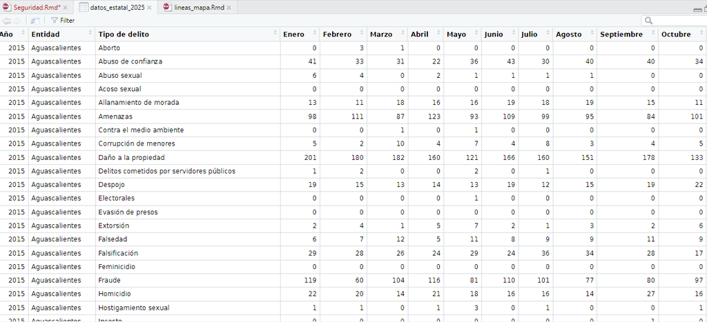

### Hidalgo_Año_y_Tipo

- Inicialmente, la base de datos `datos_estatal_2025` se había agrupado usando `group_by` para realizar ciertos análisis por grupos. Sin embargo, esta agrupación afecta el comportamiento de operaciones posteriores como `filter()`, `select()` o cálculos agregados, ya que se realizan dentro de cada grupo y no sobre el conjunto completo.  
  Por ello, se utiliza `ungroup` para eliminar la agrupación y permitir operar sobre toda la base de datos.
- Una vez desagrupada la base de datos, se filtra la columna `Entidad` para conservar únicamente aquellas filas correspondientes a Hidalgo.
- Finalmente, se seleccionan solo las columnas que son de interés:
  - `Año`
  - `Tipo de delito`
  - `total`
  - `poptot`
  - `tasa`
- Se guarda.

### delitos por mes_15-24_estatal.csv

- Inicialmente, la base de datos `datos_estatal_2025` se había agrupado usando `group_by` para realizar ciertos análisis por grupos. Sin embargo, esta agrupación afecta el comportamiento de operaciones posteriores como `filter()`, `select()` o cálculos agregados, ya que se realizan dentro de cada grupo y no sobre el conjunto completo.  
  Por ello, se utiliza `ungroup` para eliminar la agrupación y permitir operar sobre toda la base de datos.
- Una vez desagrupada la base de datos, se filtra la columna `Entidad` para conservar únicamente aquellas filas correspondientes a Hidalgo.
- Se realiza un `tidyr::pivot_longer(cols = c(Enero:Diciembre),names_to = "Mes",values_to = "Conteo")` la definicion de `pivot_longer` nos dice que: “alarga” los datos, aumentando el número de filas y reduciendo el número de columnas. En este caso convierte las columnas de los meses (de Enero a Diciembre) en filas. El nombre del mes se almacena en la columna `Mes`, y los valores originales de esas columnas se guardan en la columna `Conteo`. En términos sencillos y no formales, es como hacer una transposición de matriz pero solo de una parte.
- Despues, se seleccionan solo las columnas que son de interés:
  - `Año`
  - `Tipo de delito`
  - `Mes`
  - `Conteo`
- Finalmente vamos a definir una condicional para la columna de `Conteo` donde si tenemos que un valor de `Conteo` es NA, este lo llenara con 0 y en caso que exista un numero este lo dejara igual.
- Se guarda.

### tasa_media_nacional

- Inicialmente, la base de datos `datos_estatal_2025` se había agrupado usando `group_by` para realizar ciertos análisis por grupos. Sin embargo, esta agrupación afecta el comportamiento de operaciones posteriores como `filter()`, `select()` o cálculos agregados, ya que se realizan dentro de cada grupo y no sobre el conjunto completo.  
  Por ello, se utiliza `ungroup` para eliminar la agrupación y permitir operar sobre toda la base de datos.
- Despues, se seleccionan solo las columnas que son de interés:
  - `Año`
  - `Tipo de delito`
  - `tasa`
- Se vuelve agrupar por `Año` y `Tipo de delito`con un `group_by`.
- Ademas se crean dos variables mas llamada `tasa_media` y `tasa_mediana` apartir de un `summarise`
- Se guarda.
- *Nota:* Puede variar con los historicos porque los reclasifican

### Base hidalgo_municipal_2025_2

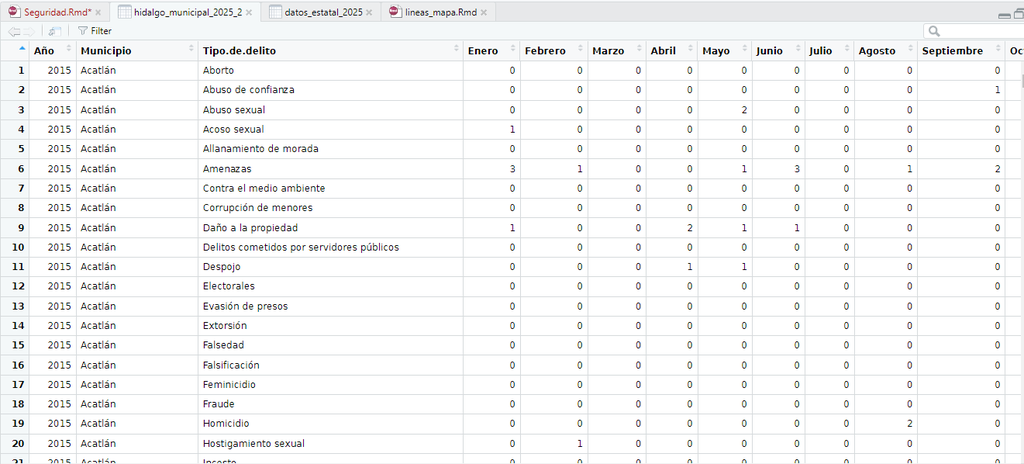

### delitos por mes_15-24.csv

### Municipal_Año_y_Tipo.csv

*Se hacen analogos que los anteriores*.

### Notas para mi:

- Comprimir la carpeta pero quitando el archivo que se subio dado que este no se hace uso en JavaScrip ademas es una manera de ser respetuoso con el servidor y mandarlo a Brayan.
- Checar la cantidad de delitos que sean **40** dado que lo pueden actualizar.
- Dentro de **VisualCode** solo moverle al archivo HTML llamado **tablero_seguridad** en el apartado de `"hasta tal mes"`

[figure not shown]